# **ExtraaLearn Project**

### **Decision Tree Pruning**

As observed in the previous section, the initial Decision Tree Classifier model showed significant overfitting, performing exceptionally well on the training data but poorly on unseen test data. To address this, we will apply **pruning** techniques to the Decision Tree. Pruning helps to simplify the tree by removing branches that do not contribute significantly to improving accuracy on the training data, thereby improving the model's ability to generalize to new data and reducing the risk of overfitting.

In this section, we will use techniques like GridSearchCV to find optimal hyperparameters that control the size and complexity of the Decision Tree, effectively pruning it to achieve a better balance between bias and variance and improve its performance on the test set.

One important hyperparameter for pruning is `ccp_alpha` (Cost Complexity Pruning). It's a non-negative value used to control the complexity of the tree. Larger values of `ccp_alpha` result in more aggressive pruning, leading to smaller trees. By finding the optimal `ccp_alpha` through cross-validation, we can identify the subtree that best balances complexity and predictive accuracy on unseen data.

```python
# Define the hyperparameter grid for Decision Tree pruning
param_grid_dt = {
    'max_depth': [2, 4, 6, 8, 10, 12],
    'min_samples_split': [2, 5, 10, 20],
    'min_samples_leaf': [1, 5, 10, 20],
    'ccp_alpha': [0.0, 0.001, 0.01, 0.1]
}

# Print the defined hyperparameter grid
print(param_grid_dt)
```

```
{'max_depth': [2, 4, 6, 8, 10, 12], 'min_samples_split': [2, 5, 10, 20], 'min_samples_leaf': [1, 5, 10, 20], 'ccp_alpha': [0.0, 0.001, 0.01, 0.1]}
```

```python
# Initialize Decision Tree Classifier model
dt_model = DecisionTreeClassifier(random_state=42)

# Initialize GridSearchCV
grid_search_dt = GridSearchCV(estimator=dt_model, param_grid=param_grid_dt,
                             cv=5, scoring='roc_auc', n_jobs=-1) # Using roc_auc as the scoring metric

# Fit GridSearchCV to the training data
grid_search_dt.fit(X_train, y_train)

# Print the best hyperparameters found by GridSearchCV
print("Best hyperparameters found by GridSearchCV:", grid_search_dt.best_params_)
```

```
Best hyperparameters found by GridSearchCV: {'ccp_alpha': 0.001, 'max_depth': 8, 'min_samples_leaf': 20, 'min_samples_split': 2}
```

```python
# Initialize a new Decision Tree model with the best hyperparameters found by GridSearchCV
pruned_dt_model = DecisionTreeClassifier(**grid_search_dt.best_params_, random_state=42)

# Train the pruned model and measure training time
start_time = time.time()
pruned_dt_model.fit(X_train, y_train)
training_time_pruned_dt = time.time() - start_time

# Make predictions on the training and testing sets and measure prediction time
start_time = time.time()
y_train_pred_pruned_dt = pruned_dt_model.predict(X_train)
train_prediction_time_pruned_dt = time.time() - start_time

start_time = time.time()
y_test_pred_pruned_dt = pruned_dt_model.predict(X_test)
test_prediction_time_pruned_dt = time.time() - start_time

# Get predicted probabilities for the testing set
y_test_proba_pruned_dt = pruned_dt_model.predict_proba(X_test)[:, 1]

# Evaluate the pruned model
test_report_pruned_dt = classification_report(y_test, y_test_pred_pruned_dt, output_dict=True)
test_roc_auc_pruned_dt = roc_auc_score(y_test, y_test_proba_pruned_dt)

# Store results in the dictionary
model_results['Pruned Decision Tree'] = {
    'Training Report': classification_report(y_train, y_train_pred_pruned_dt, output_dict=True),
    'Training ROC AUC': roc_auc_score(y_train, pruned_dt_model.predict_proba(X_train)[:, 1]),
    'Training Confusion Matrix': confusion_matrix(y_train, y_train_pred_pruned_dt).tolist(),
    'Training Time (s)': training_time_pruned_dt,
    'Training Prediction Time (s)': train_prediction_time_pruned_dt,
    'Testing Report': test_report_pruned_dt,
    'Testing ROC AUC': test_roc_auc_pruned_dt,
    'Testing Confusion Matrix': confusion_matrix(y_test, y_test_pred_pruned_dt).tolist(),
    'Testing Prediction Time (s)': test_prediction_time_pruned_dt,
    'Testing Probabilities': y_test_proba_pruned_dt.tolist() # Store testing probabilities
}
```

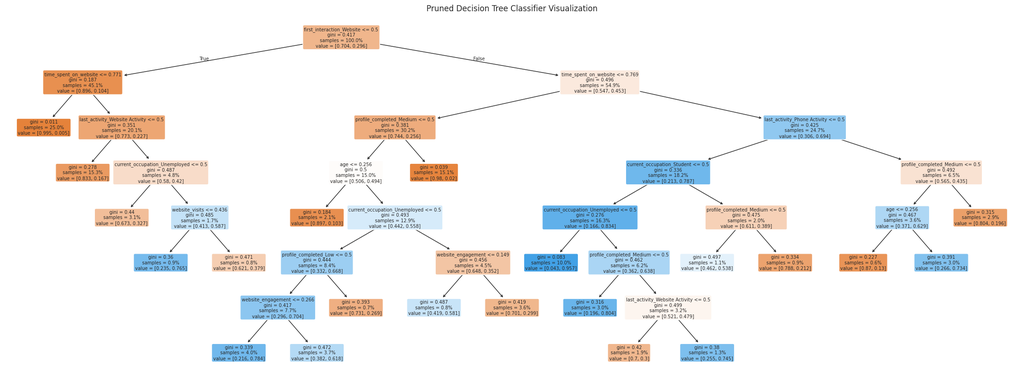

```python
# Set the figure size for the plot
plt.figure(figsize=(28, 10))

# Plot the decision tree
plot_tree(pruned_dt_model, # The trained Decision Tree model
          feature_names=X_train.columns, # Use column names from the training data as feature names
          filled=True, # Color nodes to indicate the majority class
          proportion=True, # Display the proportion of samples in each node
          rounded=True, # Round the corners of the decision tree nodes
          fontsize=7) # Set the font size for text within the nodes

plt.title("Pruned Decision Tree Classifier Visualization")
plt.show()
```

```
Model Comparison Table (Sorted by Test ROC AUC):
```

|  | Accuracy (Train) | Precision (Train - Converted) | Recall (Train - Converted) | F1-score (Train - Converted) | ROC AUC (Train) | Accuracy (Test) | Precision (Test - Converted) | Recall (Test - Converted) | F1-score (Test - Converted) | ROC AUC (Test) | Training Time (s) | Prediction Time (s) |
| --- | --- | --- | --- | --- | --- | --- | --- | --- | --- | --- | --- | --- |
| Pruned Decision Tree | 0.873029 | 0.802927 | 0.756434 | 0.778987 | 0.925634 | 0.860870 | 0.806950 | 0.728223 | 0.765568 | 0.919101 | 0.028307 | 0.003221 |
| Logistic Regression | 0.834693 | 0.769663 | 0.629596 | 0.692619 | 0.867507 | 0.844565 | 0.788000 | 0.686411 | 0.733706 | 0.883454 | 0.063303 | 0.013574 |
| Decision Tree | 0.999728 | 1.000000 | 0.999081 | 0.999540 | 1.000000 | 0.810870 | 0.687708 | 0.721254 | 0.704082 | 0.786378 | 0.035452 | 0.002146 |

```
--- Confusion Matrices for Top 3 Models (Based on Test ROC AUC) ---
```

```
Feature Importances (Pruned Decision Tree):
```

|  | 0 |
| --- | --- |
| time_spent_on_website | 0.278925 |
| first_interaction_Website | 0.266152 |
| profile_completed_Medium | 0.195235 |
| current_occupation_Unemployed | 0.066946 |
| last_activity_Phone Activity | 0.052226 |
| age | 0.049952 |
| last_activity_Website Activity | 0.034032 |
| current_occupation_Student | 0.030626 |
| profile_completed_Low | 0.010820 |
| website_engagement | 0.009507 |
| website_visits | 0.005580 |
| page_views_per_visit | 0.000000 |
| print_media_type1_Yes | 0.000000 |
| digital_media_Yes | 0.000000 |
| print_media_type2_Yes | 0.000000 |
| educational_channels_Yes | 0.000000 |
| referral_Yes | 0.000000 |
| interaction_score | 0.000000 |
| media_interaction | 0.000000 |

**dtype:** float64

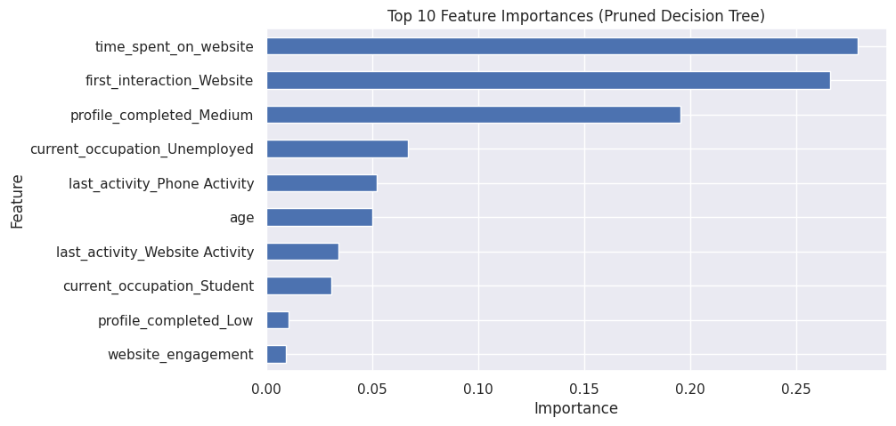

```python
# Display the model comparison table after Pruned Decision Tree and capture the sorted DataFrame
results_df_sorted = display_model_comparison_table(model_results)

# Plot confusion matrices for the top models
plot_top_n_confusion_matrices(model_results, results_df_sorted, 3)

# Display feature importance for the Decision Tree model
display_feature_importance(pruned_dt_model, X_train.columns, 'Pruned Decision Tree')
```

[output not shown]